# Gaffke’s confidence bound

2021-12-16

## Overview

This notebook discusses an as-yet-unproven method for conservative, finite-sample, nonparametric inference on the population mean when random variables are drawn from an arbitrary bounded distribution. A robust test of the one-sided null $H_0: \mu \leq \mu_0$ is provided. From this we can derive a test of the two-sided hypothesis $H_0: \mu = \mu_0$, a two-sample test like $H_0: \mu_X = \mu_Y$, or a confidence bound or interval for $\mu$. The inference is *valid* — tests have the right level, intervals have the right coverage — at any sample size $n$ with no assumptions other than boundedness, which is very mild and realistic in many practical settings. In contrast, the typical approach to inference based on Student’s $t$-test has no finite-sample performance guarantees for bounded distributions: the level of Student’s $t$-test can be arbitrarily high, and is especially bad for skewed distributions. We now draw out the context for this work before presenting the proposed test.

## Confidence bounds and sequences

We have an IID sample of $n$ bounded random variables such that $Y_i \in [0,1]$. These can be stacked into a random vector $\boldsymbol{Y} = [Y_1,...,Y_n]^T$. The unknown distribution of $Y_i$ is $F$ with mean $\mu(F) \equiv \mathbb{E}[Y_1]$. We know that $F \in \mathcal{F}_{[0,1]}$, the set of all distributions supported on $[0,1]$.

We want to test the hypothesis $H_0: \mu(F) \leq \mu_0$ vs $H_1: \mu(F) > \mu_0$. Consider a test represented by the critical function $\phi(\boldsymbol{Y})$ that is equal to 1 if we reject $H_0$ and 0 otherwise. The probability of rejection when $Y_i \sim F$ is $\mathbb{E}_F[\phi(\boldsymbol{Y})]$, and we seek a test $\phi$ so that:
$$\mathbb{E}_F[\phi(\boldsymbol{Y})] \leq \alpha ~~\mbox{for all}~~ F \in \mathcal{F}_{[0,1]} ~~\mbox{with}~~ \mu(F) \leq \mu_0$$
Note that, given such a test, we can exploit the duality of tests and confidence bounds to construct an upper one-sided bound $C_u(\boldsymbol{Y})$ so that
$$\mathbb{P}_F(C_u(\boldsymbol{Y}) \geq \mu(F) ) \geq 1-\alpha ~~\mbox{for all}~~ F \in \mathcal{F}_{[0,1]}.$$
Vice versa, we can invert a level $(1-\alpha)$ confidence bound to get a level $\alpha$ test. We can also get two-sided tests and confidence intervals by constructing two one-sided intervals, one from the original samples $Y_i$ and one from the reflections $1-Y_i$ and $1-\mu_0$, since $\mathbb{E}[1-Y_i] \leq 1-\mu_0 \implies \mathbb{E}[Y_i] \geq \mu_0$. We alternate between referring to tests and bounds, with the understanding that they provide equivalent inferences in a technical sense.

## Other methods

A number of bounds for RVs supported on $[0,1]$ have already been proposed. An incomplete list includes:

**Fixed sample bounds**:

- Hoeffding’s bound for sub-Gaussians
- [Empirical Bernstein bounds](http://arxiv.org/abs/0907.3740), which adapt to the variance of $F$
- [The Stringer bound](https://www.jstor.org/stable/1403650), widely used in auditing
- [Penny sampling](https://doi.org/10.1093/jssam/smv025), also used in auditing
- [Anderson’s bound](https://apps.dtic.mil/sti/citations/AD0696676) derived from bounds on the ECDF
- [Romano and Wolf’s bound](https://projecteuclid.org/journals/annals-of-statistics/volume-28/issue-3/Finite-sample-nonparametric-inference-and-large-sample-efficiency/10.1214/aos/1015951997.full) also derived from a bound on the ECDF and shown to be asympotically efficient.

**Sequentially valid bounds**:

- [Exponential supermartingales](http://arxiv.org/abs/1810.08240), which hold for a broader class of distributions than bounded $F$ and include the well-known sequential likelihood ratio tests (e.g. Wald’s SPRT).
- [Betting martingales](https://arxiv.org/pdf/2010.09686.pdf), generally sharper than exponential supermartingales and related to [empirical](https://doi.org/10.1093/biomet/75.2.237) / [nonparametric](https://www.sciencedirect.com/science/article/pii/S0378375801002944) likelihood ratios.

## Gaffke’s statistic

In an obscure, [2004 paper](https://www.math.uni-magdeburg.de/institute/imst/ag_gaffke/files/pp1304.pdf), Norbert Gaffke proposed a fairly simple bound. Suppose we have $\boldsymbol{D}^T = [D_1,...,D_n] \sim \mbox{Dirichlet(1,...,1)}$, a uniform draw from the $n$-dimensional simplex, and let $Q(G, \alpha)$ be the function returning the $\alpha$-quantile of distribution $G$. Denote a given (fixed) observation of $Y_i$ as $y_i$ and consider the function:
$$\begin{align}
G(\boldsymbol{y}) \equiv \mathbb{P}_{\boldsymbol{D}}\left (\sum_{i=1}^{n+1} y_i D_i \geq \mu_0 \right )
\end{align}$$
where $y_{n+1} = 1$. The proposed test is

$$\phi(\boldsymbol{y}) = \begin{cases} 1 & \mbox{if}~ G(\boldsymbol{y}) < \alpha \\ 0 & \mbox{if}~ G(\boldsymbol{y}) \geq \alpha \end{cases}$$
If it holds that
$$\mathbb{E}_F[\phi(\boldsymbol{Y})] \leq \alpha ~~\mbox{for all}~~ F \in \mathcal{F}_{[0,1]} ~~\mbox{with}~~ \mu(F) \geq \mu_0$$
then $G(\boldsymbol{y})$ is a valid p-value for the test. This is conjectured by both LMT and Gaffke, but remains an open question.

## Computation

$G(\boldsymbol{y})$ is very straightforward to approximate using Monte Carlo: draw $\{\boldsymbol{D}_1,\boldsymbol{D}_2,...,\boldsymbol{D}_B\}$ from the Dirichlet distribution to get $\{G_1(\boldsymbol{y}), G_2(\boldsymbol{y}),...,G_B(\boldsymbol{y})\}$ and compute the tail probability:
$$\tilde{G}(\boldsymbol{y}) = \frac{1}{B} \sum_{b=1}^B 1\{ G_b(\boldsymbol{y}) \geq \mu_0 \}.$$

Denote $Q(x, \alpha)$ as the $\alpha$ quantile of a vector $x$, and $\boldsymbol{G} = [G_1(\boldsymbol{y}), G_2(\boldsymbol{y}),...,G_B(\boldsymbol{y})]^T$ as the vector obtaind by concatenating the Monte Carlo draws from the distribution of $G(\boldsymbol{y})$. Then an upper $(1-\alpha)$ confidence bound on $\mu$ is readily estimated using the Monte Carlo distribution as:
$$C_u(\boldsymbol{Y}) \equiv Q\big (\boldsymbol{G}, 1-\alpha \big )$$

## Relation to the bootstrap

The usual nonparametric bootstrap of the sample mean can be written:
$$\frac{1}{n} \sum_{i=1}^n y_i M_i ~~\mbox{where}~~ [M_1,...,M_n]^T \sim \mbox{Multinomial}(\boldsymbol{1}_n / n).$$
The Bayesian bootstrap of the mean is given by
$$\sum_{i=1}^n y_i D_i ~~\mbox{where}~~ [D_1,...,D_n]^T \sim \mbox{Dirichlet}(\boldsymbol{1}_n)$$
(see [Rubin, 1981](https://projecteuclid.org/journals/annals-of-statistics/volume-9/issue-1/The-Bayesian-Bootstrap/10.1214/aos/1176345338.full)). The Bayesian boostrap is a ``smoothed" version of the usual nonparametric bootstrap. Both take random convex combinations of the sample, but while the usual bootstrap weights can only take on fractional integer values, the Bayesian bootstrap weights may be any number on [0,1].

$G(\boldsymbol{y}) = \sum_{i=1}^{n+1} y_i D_i$ is a simple modification to the Bayesian bootstrap. It augments the random sample with a single point equal to the upper bound of the support, runs the Bayesian bootstrap, and takes the upper tail of the Bootstrap distribution. It can also be written as the usual Bayesian boostrap without sample augmentation but with a particular prior. Take $F$ to be a discrete distribution (including, for example, any finite-population) with points at $\boldsymbol{d} = [d_1,...,d_K]$ and let $\mathbb{P}(Y = d_k | \boldsymbol{\theta}) = \theta_k$ so that $\boldsymbol{\theta}$ is the corresponding vector of probabilities characterizing the likelihood of $Y$. In a given sample $Y_1,...,Y_n$ take $n_k = \#\{Y_i = d_k\}$. As an aside, the “nonparametric” maximum likelihood estimate (NPMLE) of $\theta$ is $\hat{\theta}_{\tiny \mbox{mle}} = \frac{n_k}{n}$, which corresponds to the empirical CDF. Nonparametric likelihood ratios involving the NPMLE can be used to construct asymptotically valid confidence intervals calibrated to the $\chi^2$ distribution ([Owen (2001)](https://artowen.su.domains/empirical/)). To complete the Bayesian construction, consider putting a prior on $\boldsymbol\theta$ of the form:
$$\mathbb{P}(\boldsymbol{\theta}) \propto \prod_{k=1}^K \theta_k^{l_k}$$
Then the posterior distribution of $\boldsymbol\theta$ is $\mbox{Dirichlet}(n_1 + l_1 + 1,...,n_K + l_K + 1)$:
$$\mathbb{P}(\boldsymbol{\theta} \mid Y_1,...,Y_n) \propto \prod_{k=1}^K \theta_k^{(n_k + l_k)}$$
Suppose $d_1 \leq ,..., d_K = 1$, so $d_K$ is set to the largest possible value it can take. The posterior that gives $G(\boldsymbol{y})$ is:
$$\mathbb{P}(\boldsymbol{\theta} \mid Y_1,...,Y_n) \propto \left [ \prod_{k=1}^{K-1} \theta_k^{n_k} \right ] \times \theta_K^{n_K + 1}$$
which comes from the usual Bayesian formula with prior:
$$\mathbb{P}(\boldsymbol{\theta}) \propto \left[ \prod_{k=1}^{K-1} \theta_k^{0} \right ] \times \theta_K$$
So the prior is $\theta \sim \mbox{Dirichlet}([1,...,1,2])$.

[TODO: Check work, more connections to empirical likelihood, connection to least favorable priors?]

## Gaffke is optimal for binary populations

If we knew that $Y_i \sim \mbox{Bernoulli}(\mu)$, then the uniformly most powerful test of $H_0: \mu \geq \mu_0$ is given by the lower tail of the binomial distribution:
$$\sum_{j=0}^{k} {n \choose j} \mu_0^j (1-\mu_0)^{n-j}$$
where $k = \sum_i y_i$ is the number of 1s observed in the sample. This follows from the Neyman-Pearson lemma and the fact that the Binomial has a monotone likelihood ratio. This test is conservative due to the discreteness of the tail, but it can be randomized to exactness.

To see the equivalence between these $p$-values, note that the binomial tail $\sum_{i=0}^{k} {n \choose j} \mu_0^j (1-\mu_0)^{n-j}$ is equal to the probability of drawing $n$ $\mbox{Uniform}[0,1]$ random variables, and observing $k$ or fewer below $\mu_0$ with the rest above $\mu_0$. In other words, the probability of drawing $n$ standard uniforms and observing the $k+1$ order statistic to be above $\mu_0$. It is well known that the $k+1$ uniform order statistic has distribution:
$$U_{(k+1)} \sim \mbox{Beta}(k + 1, n-k).$$
Thus, for binary data the UMP test is $\mathbb{P}(U_{(k+1)} \geq \mu_0) = G(\boldsymbol{y})$. By inverting the test, i.e., taking the $(1-\alpha)$ quantile of $U_{(k+1)}$ we recover the classic Clopper-Pearson bound for a binomial proportion.

The upshot of this equivalence is that $G(\boldsymbol{y})$ is not only conservative for binary $Y_i$, but also the sharpest possible conservative $p$-value. Furthermore, it is not necessary to know that the population distribution is binary to utilize this advantage, though such knowledge would certainly speed computation since a closed form for $G(\boldsymbol{y})$ is available in this case. $G(\boldsymbol{y})$ can be much sharper then the binomial exact test when the population distribution is supported on the interior of $[0,1]$.

#### The Stringer Bound

Gaffke is also closely related to the stringer bound. Following the notation of [Bickel (1992)](https://www.jstor.org/stable/1403650), let $p(k; 1-\alpha)$ be the exact $1-\alpha$ upper confidence bound for $\mu$ when $Y$ is binomial. So $p(k; 1-\alpha)$ solves:
$$\sum_{j=k+1}^n {n \choose k} \mu^j (1-\mu)^{n-j} = 1-\alpha$$
for $\mu$.

Let $m = \#\{y_j = 0\}$ be the number of non-zero values in $\boldsymbol{y}$. Note $y_{(1)} = ... = y_{(m)} = 0$. The stringer bound is:

$$p(0, 1-\alpha) + \sum_{i=m}^n [p(i; 1-\alpha) - p(i-1;1-\alpha)] y_{(i)}$$

Following the logic above about uniform order statistics, $p(i, 1-\alpha) = Q(1-\alpha, U_{(i+1)})$, so the Stringer bound can be written:
$$Q(1-\alpha, U_{(1)}) + \sum_{i=m}^{n} [Q(1-\alpha, U_{(i+1-m)})-Q(1-\alpha, U_{(i-m)})] y_{(m-i)}$$
on the other hand the Gaffke bound can be written:
$$Q\left(1-\alpha, \sum_{i=1}^{n+1} y_i D_i\right ) = Q\left(1-\alpha, \sum_{i=1}^{n+1} [U_{(i)} - U_{(i-1)}] y_{(i)} \right)$$
where $U_{(0)}=0$, $U_{(n+1)}=1$ and $y_{(i+1)}=1$. This suggests an interesting relationship: the Stringer bound is a function of uniform order statistic quantiles, while the Gaffke bound is a quantile of a function of uniform order statistics. Uniform order statistics are Beta distributed, which gives their quantiles a closed form and allows the Stringer bound to be computed efficiently. On the other hand, the Gaffke bound generally requires Monte Carlo to compute (though see https://arxiv.org/abs/1412.4617 for a method based on slicing the simplex).

## Gaffke is more powerful than betting martingales

[NOTE: This section still needs work.] Gaffke *does* show that $G(\boldsymbol{y})$ is always less than the p-value given by any betting martingale. This follows from a fairly straightforward geometric argument. A betting martingale p-value is never less than:
$$B(\boldsymbol{y}) = \min_{\lambda \in [\frac{-1}{1-\mu_0},\frac{1}{\mu_0}]} \prod_{i=1}^n [1 - \lambda(y_i - \mu_0)]^{-1}.$$
We aim to show that $G(\boldsymbol{y}) \leq B(\boldsymbol{y})$. Note that
$$G(\boldsymbol{y}) = \mathbb{P}_{\boldsymbol{D}}\left (\sum_{i=1}^{n+1} y_i D_i \leq \mu_0 \right ) = n! \mbox{vol}(S_n)$$
where
$$\begin{align}
S_n &\equiv \left \{\boldsymbol{d} \in \mathbb{R}^n : d_i \geq 0, \sum_i d_i = 1, \sum_i d_i y_i \leq \mu_0 \right \}\\
&\subset \left \{\boldsymbol{d} \in \mathbb{R}^n : d_i \geq 0, \sum_i d_i \leq 1, \sum_i\frac{d_i y_i}{\mu_0} \leq 1 \right \}\\
&= \left \{\boldsymbol{d} \in \mathbb{R}^n : d_i \geq 0, \max \left \{ \sum_i d_i, \sum_i \frac{d_i y_i}{\mu_0} \right \} \leq 1 \right \}\\
&\subset \left \{\boldsymbol{d} \in \mathbb{R}^n : d_i \geq 0, (1-\lambda) \sum_i d_i + \lambda \sum_i \frac{d_i y_i}{\mu_0} \leq 1 \right \}\\
&= \left \{\boldsymbol{d} \in \mathbb{R}^n : d_i \geq 0, \sum_{i=1} (1 - \lambda + \lambda \frac{y_i}{\mu_0}) d_i \leq 1 \right \}
\end{align}$$
The volume of this final set is

$$\frac{1}{n!} \prod_{i=1}^n (1 - \lambda + \lambda \frac{y_i}{\mu_0})^{-1} = \frac{1}{n!} \prod_{i=1}^n [1 - \lambda (1 + \frac{y_i}{\mu_0})]^{-1} = \frac{1}{n!} \prod_{i=1}^n [1 - \tilde{\lambda} (y_i - \mu_0)]^{-1}$$
where $\tilde{\lambda} = - \lambda / \mu_0$.

## Gaffke is efficient

[Romano and Wolf (2000)](https://projecteuclid.org/journals/annals-of-statistics/volume-28/issue-3/Finite-sample-nonparametric-inference-and-large-sample-efficiency/10.1214/aos/1015951997.full) searched succesfully for a bound that is both conservative and asymptotically efficient when $Y_i \in [0,1]$. Efficiency in this sense means that the half-width of the confidence interval, $W_n$, converges to that of the t-test:
$$W_n \rightarrow z_{1-\alpha/2} \sigma(F) / \sqrt{n},$$
where $\sigma(F)$ is the standard deviation of $F$, which may be substantially smaller than the extremal SD of 1/2 for $Y_i \sim \mbox{Bernoulli}(0.5)$.

The Gaffke bound is efficient in this sense. We can write
$$\sum_{i=1}^{n+1} y_i D_i = D_{n+1} + \sum_{i=1}^n y_i D_i.$$
Since $D_{n+1} \sim \mbox{Beta}(1, n-1)$, using Chebyshev’s inequality we have
$$\mathbb{P}(\sqrt{n} D_{n+1} > \epsilon) \leq \epsilon^{-2} {\mathbb{V}[\sqrt{n} D_i]} = n \epsilon^{-2} {\mathbb{V}[D_i]} = \epsilon^{-2} \frac{n (n-1)}{n^2 (n+1)} = \epsilon^{-2} \frac{n-1}{n(n+1)}.$$
So that $\lim_{n\rightarrow\infty} \mathbb{P}(\sqrt{n} D_{n+1} > \epsilon) = 0$, i.e. $D_{n+1} = o_p(\sqrt{n})$. Thus, to order $o_p(\sqrt{n})$, $\sum_{i=1}^{n+1} y_i D_i$ has the same distribution as the Bayesian bootstrap, which [Lo (1987)](https://projecteuclid.org/journals/annals-of-statistics/volume-15/issue-1/A-Large-Sample-Study-of-the-Bayesian-Bootstrap/10.1214/aos/1176350271.full) shows has the same distribution as the standard bootstrap. The quantile of the standard bootstrap of the sample mean then converges to $z_{1-\alpha/2} \sigma(F) / \sqrt{n}$ (see e.g. page 652 of [Lehman and Romano, 2005](https://www.springer.com/gp/book/9780387988641)). In summary, the width of the Gaffke confidence interval is:
$$z_{1-\alpha/2} \sigma(F) / \sqrt{n} + o_p(n^{-1/2}),$$
which is the best possible. By duality, a hypothesis test based on Gaffke has a similar efficiency property: it has the same limiting power as the t-test, which is optimal.

## Gaffke is a valid p-value

This is as-yet unproven, but the empirical results are encouraging. It is clearly valid for binary populations given the equivalence to Clopper-Pearson, but the level over $\mathcal{F}_{[0,1]}$ is unproven. There is work being done by [My Phan and colleagues](https://arxiv.org/abs/2106.03163) at UMass Amherst CS. Some of their ideas appear below. [Bickel (1992)](https://www.jstor.org/stable/1403650) has some interesting explorations of the Stringer bound and modifications, which may also relate to the ideas here.

We want to show:

$$\mathbb{P}_{F_0} \left [ \mathbb{P}_{\boldsymbol{D}} \left (\sum_{i=1}^{n+1} Y_i D_i \geq \mu_0 \right ) \leq \alpha \right] \leq \alpha ~~\mbox{for all}~~ \alpha \in (0,1) , F_0 \in \mathcal{F}_{[0,1]}, \mu(F_0) \leq \mu_0$$

It is not clear how to start this.

#### An observation

My Phan used the equivalence between standard exponential and Dirichlet random variables ($Z_0,...,Z_n \sim \mbox{Exp}(1) \implies D_i = \frac{Z_i}{\sum_{j=1}^{n} Z_j}$ to find a lower bound on the Gaffke p-value:
$$G(\boldsymbol{Y}) = \mathbb{P}_{\boldsymbol{D}} \left (\sum_{i=1}^{n+1} Y_i D_i \geq \mu_0 \right ) \geq \prod_{i=1}^n \max \left \{\frac{Y_i}{\mu_0} , 1 \right \}^{-1}$$
The RHS expression looks very similar to the p-value of a betting martingale with $\lambda = \frac{1}{\mu_0}$ (sometimes called Kaplan-Markov), except for the maximum with 1. We can write:
$$\prod_{i=1}^n \max \left \{\frac{Y_i}{\mu_0} , 1 \right \}^{-1} = \prod_{i=1}^n \min\left \{\frac{\mu_0}{Y_i} , 1 \right\} = \prod_{Y_i > \mu_0} \frac{\mu_0}{Y_i}.$$
This is like the Kaplan-Markov betting martingale, except that we ignore terms that would increase the product. It is not a martingale.

Combining this with Gaffke’s proof that $G(\boldsymbol{Y})$ is always smaller than a betting martingale p-value gives a two-sided bound:
$$\prod_{Y_i > \mu_0} \frac{\mu_0}{Y_i} \leq G(\boldsymbol{Y}) \leq \prod_{i=1}^n \frac{\mu_0}{Y_i}$$
If we could show that
$$\mathbb{P}_{F_0} \left (\prod_{Y_i > \mu_0} \frac{\mu_0}{Y_i} \leq \alpha \right ) \leq \alpha$$
we would be done, but here is a counterexample. Take $F_0 = \mbox{Bernoulli}(p)$ where $p = \mu_0$, and let $k = \sum Y_i$. Then this becomes:

$$\mathbb{P}_p(p^k \leq \alpha) = \mathbb{P}_p\left (k \geq \frac{\log \alpha}{\log p} \right ) = \sum_{j = \ceil{\frac{\log \alpha}{\log p}}}^n {n \choose j} p^i (1-p)^{n-i}$$
This can be less or greater than $\alpha$ depending on $p$:

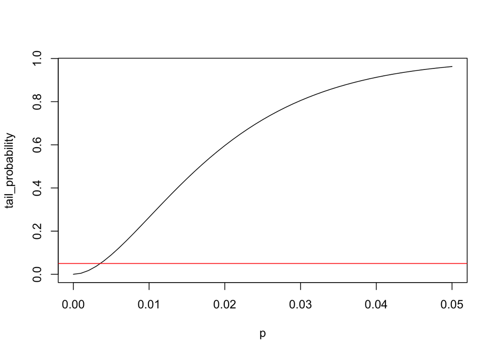

```r
n <- 100
alpha <- .05
p <- seq(0,.05,by=.001)
tail_probability <- pbinom(q = ceiling(log(alpha) / log(p)), size = n, prob = p, lower.tail = FALSE)
plot(
  x = p,
  y = tail_probability,
  type = 'l'
  )
abline(a = alpha, b = 0, col = 'red')
```

## Empirical performance

We run a few simulations to investigate the empirical performance of the Gaffke test.

### A comparison to the t-test on a skewed population disribution

For a highly skewed population, the Gaffke test maintains the right level, in this case below $\alpha = .05$, while the t-test does not.

```r
library(tidyverse)
```

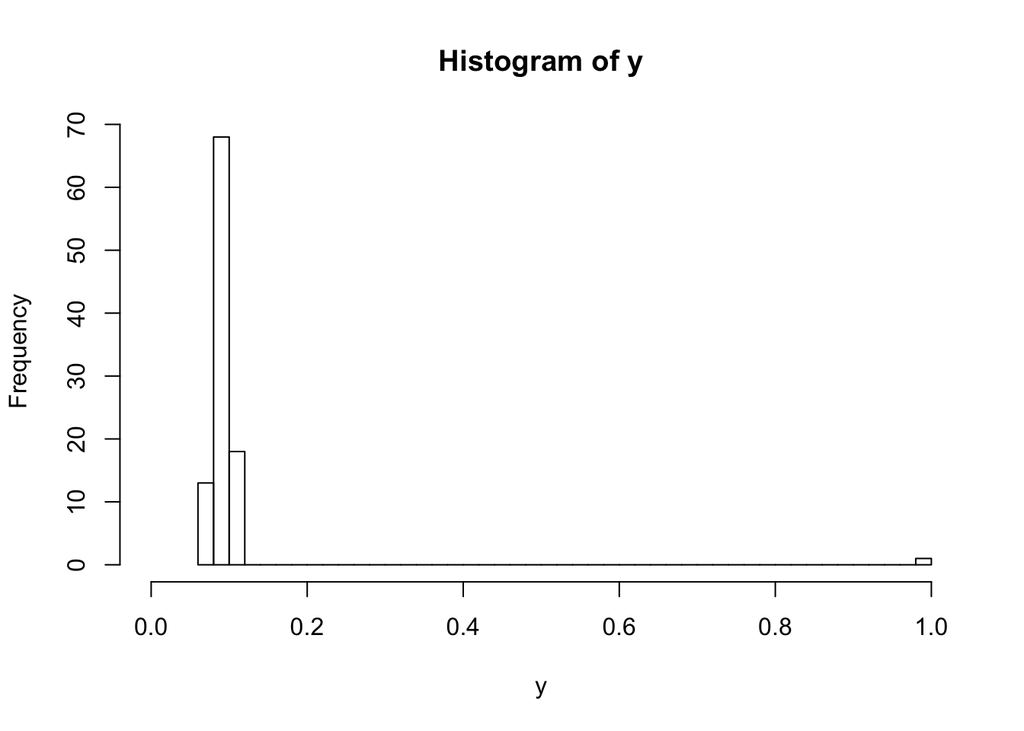

```r
B <- 200
y <- c(rnorm(99, mean = .1, sd = .01), 1)
y <- y - mean(y) + .1
hist(y, breaks = 60, xlim = c(0,1))
```

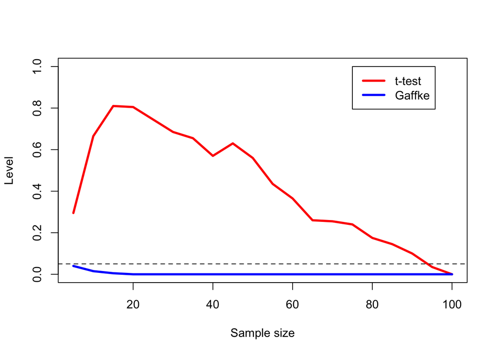

```r
n_grid <- seq(5, 100, by = 5)

gaffke_level <- rep(NA, length(n_grid))
t_level <- rep(NA, length(n_grid))

for(j in 1:length(n_grid)){
  p_ttest <- rep(NA, 200)
  p_gaffke <- rep(NA, 200)
  for(i in 1:200){
    Y <- sample(y, size = n_grid[j])
    p_ttest[i] <- t.test(x = Y, mu = .1)$p.value
    Z <- matrix(rexp(n = B * n_grid[j]), nrow = B, ncol = n_grid[j])
    D <- Z / rowSums(Z)
    p_gaffke[i] <- 1/B * sum(D %*% Y <= 0.1)
  }
  t_level[j] <- mean(p_ttest < .05)
  gaffke_level[j] <- mean(p_gaffke < .05)
}

plot(x = n_grid, y = t_level, ylim = c(0,1), col = "red", type = 'l', lwd = 3, xlab = "Sample size", ylab = "Level")
points(x = n_grid, y = gaffke_level, col = "blue", type = 'l', lwd = 3)
legend(x = 75, y = 1, lwd = 3, col = c("red","blue"), legend = c("t-test","Gaffke"))
abline(0.05, 0, lty = "dashed")
```

### Replicating part of Tables 1 and 2 from Romano and Wolf (2000)

```r
#functions to get confidence bounds
Gaffke_CB <- function(x, alpha = .05, B = 200, side = "upper"){
  n <- length(x)
  if(side == "lower"){
    x <- 1 - x
  }
  z <- sort(x, decreasing = FALSE)
  ms <- rep(NA, B)
  s <- c(diff(z), 1 - z[n])
  for(i in 1:B){
    #this uses the equivalence of differences of uniform order statistics and Dirichlet RVs
    u <- sort(runif(n), decreasing = FALSE)
    ms[i] <- 1 - sum(u * s)
  }
  ms_alpha <- quantile(ms, 1 - alpha)
  if(side == "lower"){
    1 - ms_alpha
  } else if(side == "upper"){
    ms_alpha
  }
}
Stringer_CB <- function(x, alpha = .05, side = "upper"){
  n <- length(x)
  if(side == "lower"){
    x <- 1 - x
  }
  z <- sort(x)
  m <- sum(z != 0)
  p <- rep(NA, m+1)

  for(i in 0:m){
    if(i == n){
      p[i+1] <- 1
    } else{
      p[i+1] <- uniroot(
        function(p){pbinom(q = i, size = n, prob = p, lower.tail = FALSE) - (1-alpha)},
        interval = c(0,1)
      )$root
    }
  }
  stringer_bound <- p[1] + sum(diff(p) * z[n:(n+1-m)])
  if(side == "lower"){
    1 - stringer_bound
  } else if(side == "upper"){
    stringer_bound
  }
}

get_CLT_CI <- function(x){
  n <- length(x)
  c(mean(x) - qnorm(.975) * sd(x) / sqrt(n), mean(x) + qnorm(.975) * sd(x) / sqrt(n))
}
get_Gaffke_CI <- function(x){
  c(Gaffke_CB(x = x, alpha = .025, side = "lower"), Gaffke_CB(x = x, alpha = .025, side = "upper"))
}
get_Stringer_CI <- function(x){
  c(Stringer_CB(x = x, alpha = .025, side = "lower"), Stringer_CB(x = x, alpha = .025, side = "upper"))
}
#functions to help simulate from distributions specified in Romano / Wolf
triangle_quantile <- function(q){
  ifelse(q < 1/2, sqrt(q/2), 1 - sqrt(1-q)/sqrt(2))
}
inverted_triangle_quantile <- function(q){
  #the thresholding here with pmin/pmax is just to prevent ifelse from throwing a useless warning
  ifelse(q < 1/2, 0.5 * (1 - sqrt(1 - 2*pmin(q,.5))), 0.5 * (1 + sqrt(2*pmax(q,.5) - 1)))
}
skewed_triangle_quantile <- function(q){
  sqrt(q)
}

B <- 1000
n_grid <- c(10, 30)
populations <- c("Uniform", "Triangle", "Inverted-Triangle", "Skewed-Triangle", "Two-Point")

width_frame_CLT <- expand.grid(
  n = n_grid,
  population = populations
) %>%
  mutate(metric = "Width", method = "CLT", value = NA)
coverage_frame_CLT <- expand.grid(
  n = n_grid,
  population = populations
) %>%
  mutate(metric = "Coverage", method = "CLT", value = NA)
width_frame_Gaffke <- expand.grid(
  n = n_grid,
  population = populations
) %>%
  mutate(metric = "Width", method = "Gaffke", value = NA)
coverage_frame_Gaffke <- expand.grid(
  n = n_grid,
  population = populations
) %>%
  mutate(metric = "Coverage", method = "Gaffke", value = NA)
width_frame_Stringer <- expand.grid(
  n = n_grid,
  population = populations
) %>%
  mutate(metric = "Width", method = "Stringer", value = NA)
coverage_frame_Stringer <- expand.grid(
  n = n_grid,
  population = populations
) %>%
  mutate(metric = "Coverage", method = "Stringer", value = NA)


for(i in 1:nrow(width_frame_CLT)){
  if(width_frame_CLT$population[i] == "Uniform"){
    Gaffke_CIs <- t(replicate(B, get_Gaffke_CI(x = runif(n = width_frame_Gaffke$n[i]))))
    Stringer_CIs <- t(replicate(B, get_Stringer_CI(x = runif(n = width_frame_Stringer$n[i]))))
    CLT_CIs <- t(replicate(B, get_CLT_CI(x = runif(n = width_frame_CLT$n[i]))))
    coverage_Gaffke <- mean(Gaffke_CIs[,1] <= 0.5 & Gaffke_CIs[,2] >= 0.5)
    coverage_Stringer <- mean(Stringer_CIs[,1] <= 0.5 & Stringer_CIs[,2] >= 0.5)
    coverage_CLT <- mean(CLT_CIs[,1] <= 0.5 & CLT_CIs[,2] >= 0.5)
  } else if(width_frame_CLT$population[i] == "Triangle"){
    Gaffke_CIs <- t(replicate(B, get_Gaffke_CI(x = triangle_quantile(runif(n = width_frame_Gaffke$n[i])))))
    Stringer_CIs <- t(replicate(B, get_Stringer_CI(x = triangle_quantile(runif(n = width_frame_Stringer$n[i])))))
    CLT_CIs <- t(replicate(B, get_CLT_CI(x = triangle_quantile(runif(n = width_frame_CLT$n[i])))))
    coverage_Gaffke <- mean(Gaffke_CIs[,1] <= 0.5 & Gaffke_CIs[,2] >= 0.5)
    coverage_Stringer <- mean(Stringer_CIs[,1] <= 0.5 & Stringer_CIs[,2] >= 0.5)
    coverage_CLT <- mean(CLT_CIs[,1] <= 0.5 & CLT_CIs[,2] >= 0.5)
  } else if(width_frame_CLT$population[i] == "Inverted-Triangle"){
    Gaffke_CIs <- t(replicate(B, get_Gaffke_CI(x = inverted_triangle_quantile(runif(n = width_frame_Gaffke$n[i])))))
    Stringer_CIs <- t(replicate(B, get_Stringer_CI(x = inverted_triangle_quantile(runif(n = width_frame_Stringer$n[i])))))
    CLT_CIs <- t(replicate(B, get_CLT_CI(x = inverted_triangle_quantile(runif(n = width_frame_CLT$n[i])))))
    coverage_Gaffke <- mean(Gaffke_CIs[,1] <= 0.5 & Gaffke_CIs[,2] >= 0.5)
    coverage_Stringer <- mean(Stringer_CIs[,1] <= 0.5 & Stringer_CIs[,2] >= 0.5)
    coverage_CLT <- mean(CLT_CIs[,1] <= 0.5 & CLT_CIs[,2] >= 0.5)
  } else if(width_frame_CLT$population[i] == "Skewed-Triangle"){
    Gaffke_CIs <- t(replicate(B, get_Gaffke_CI(x = skewed_triangle_quantile(runif(n = width_frame_Gaffke$n[i])))))
    Stringer_CIs <- t(replicate(B, get_Stringer_CI(x = skewed_triangle_quantile(runif(n = width_frame_Stringer$n[i])))))
    CLT_CIs <- t(replicate(B, get_CLT_CI(x = skewed_triangle_quantile(runif(n = width_frame_CLT$n[i])))))
    coverage_Gaffke <- mean(Gaffke_CIs[,1] <= 2/3 & Gaffke_CIs[,2] >= 2/3)
    coverage_Stringer <- mean(Stringer_CIs[,1] <= 2/3 & Stringer_CIs[,2] >= 2/3)
    coverage_CLT <- mean(CLT_CIs[,1] <= 2/3 & CLT_CIs[,2] >= 2/3)
  } else if(width_frame_CLT$population[i] == "Two-Point"){
    Gaffke_CIs <- t(replicate(B, get_Gaffke_CI(x = rbinom(n = width_frame_Gaffke$n[i], size = 1, p = .05))))
    Stringer_CIs <- t(replicate(B, get_Stringer_CI(x = rbinom(n = width_frame_Stringer$n[i], size = 1, p = .05))))
    CLT_CIs <- t(replicate(B, get_CLT_CI(x = rbinom(n = width_frame_CLT$n[i], size = 1, p = .05))))
    coverage_Gaffke <- mean(Gaffke_CIs[,1] <= 0.05 & Gaffke_CIs[,2] >= 0.05)
    coverage_Stringer <- mean(Stringer_CIs[,1] <= 0.05 & Stringer_CIs[,2] >= 0.05)
    coverage_CLT <- mean(CLT_CIs[,1] <= 0.05 & CLT_CIs[,2] >= 0.05)
  }
  width_frame_Gaffke$value[i] <- mean(Gaffke_CIs[,2] - Gaffke_CIs[,1])
  width_frame_CLT$value[i] <- mean(CLT_CIs[,2] - CLT_CIs[,1])
  width_frame_Stringer$value[i] <- mean(Stringer_CIs[,2] - Stringer_CIs[,1])
  coverage_frame_Gaffke$value[i] <- coverage_Gaffke
  coverage_frame_Stringer$value[i] <- coverage_Stringer
  coverage_frame_CLT$value[i] <- coverage_CLT
}

coverage_frame <- bind_rows(
  coverage_frame_CLT,
  coverage_frame_Gaffke,
  coverage_frame_Stringer
)
width_frame <- bind_rows(
  width_frame_CLT,
  width_frame_Gaffke,
  width_frame_Stringer
) %>%
  mutate(value = round(value, 2))


coverage_table <- coverage_frame %>%
  pivot_wider(names_from = "method", values_from = "value")
width_table <- width_frame %>%
  pivot_wider(names_from = "method", values_from = "value")

#table 1
coverage_table
```

| n | population | metric | CLT | Gaffke | Stringer |
| --- | --- | --- | --- | --- | --- |
| 10 | Uniform | Coverage | 0.909 | 0.991 | 1.000 |
| 30 | Uniform | Coverage | 0.957 | 0.982 | 0.997 |
| 10 | Triangle | Coverage | 0.922 | 1.000 | 1.000 |
| 30 | Triangle | Coverage | 0.942 | 0.994 | 1.000 |
| 10 | Inverted-Triangle | Coverage | 0.914 | 0.986 | 0.996 |
| 30 | Inverted-Triangle | Coverage | 0.939 | 0.961 | 0.991 |
| 10 | Skewed-Triangle | Coverage | 0.903 | 0.996 | 0.999 |
| 30 | Skewed-Triangle | Coverage | 0.935 | 0.991 | 0.998 |
| 10 | Two-Point | Coverage | 0.448 | 0.989 | 0.994 |
| 30 | Two-Point | Coverage | 0.771 | 0.982 | 0.982 |

```r
#table 2
width_table
```

| n | population | metric | CLT | Gaffke | Stringer |
| --- | --- | --- | --- | --- | --- |
| 10 | Uniform | Width | 0.35 | 0.42 | 0.51 |
| 30 | Uniform | Width | 0.21 | 0.23 | 0.30 |
| 10 | Triangle | Width | 0.25 | 0.36 | 0.45 |
| 30 | Triangle | Width | 0.14 | 0.18 | 0.25 |
| 10 | Inverted-Triangle | Width | 0.44 | 0.47 | 0.54 |
| 30 | Inverted-Triangle | Width | 0.25 | 0.27 | 0.33 |
| 10 | Skewed-Triangle | Width | 0.28 | 0.38 | 0.47 |
| 30 | Skewed-Triangle | Width | 0.17 | 0.20 | 0.27 |
| 10 | Two-Point | Width | 0.19 | 0.36 | 0.37 |
| 30 | Two-Point | Width | 0.13 | 0.18 | 0.19 |

### Comparison to a deterministic lower bound

For any $Y_i \sim F$ such that $Y_i \geq 0$ the tail-sum formula gives $\mu = 1 - \int_0^\infty F(x) dx = \int_0^1 F^{-1}(x) dx$. Given $\{U_i\}_{i=1}^n \overset{iid}{\sim} \mbox{Uniform}[0,1]$, consider the random variable
$$G(\boldsymbol{Y},\boldsymbol{U}) = \sum_{i=1}^n F^{-1}(U_{(i)}) (U_{(i)} - U_{(i-1)}) = \sum_{i=1}^n Y_{(i)} (U_{(i+1)} - U_{(i)})$$
where $U_{(n+1)} = 1$ and $Y_{(i)}$ are the (observed) order statistics of the sample. $G(\boldsymbol{Y},\boldsymbol{U})$ is essentially a lower Reimann approximation to $\int_0^1 F^{-1}(x)dx = \mu$, so $G(\boldsymbol{Y},\boldsymbol{U}) \leq \mu$. Furthermore, for new uniform random variables $\{V_i\}_{i=1}^n \overset{iid}{\sim} \mbox{Uniform}[0,1]$ the Gaffke lower bound is just $Q(\alpha, G(\boldsymbol{Y},\boldsymbol{V}))$.

```r
n_sims <- 1000
B <- 200
n <- 5
G_Y_U <- rep(NA, n_sims)
G_Y_V <- matrix(NA, nrow = n_sims, ncol = B)
for(i in 1:n_sims){
  #uniform F
  U_sorted <- sort(runif(n))
  V_sorted <- sort(runif(n))
  G_Y_U[i] <- sum(U_sorted * diff(c(U_sorted, 1)))
  G_Y_V[i,] <- replicate(B, sum(U_sorted * diff(c(sort(runif(n)), 1))))
}
Q_G_V <- apply(G_Y_V, 1, quantile, .05)

#proportion of time the quantile of G(Y,V) is below G(Y,U)
mean(Q_G_V <= G_Y_U)
```

```
## [1] 0.903
```

```r
#proportion of time the quantile of G(Y,V) is below true mean
mean(Q_G_V <= 0.5)
```

```
## [1] 0.999
```

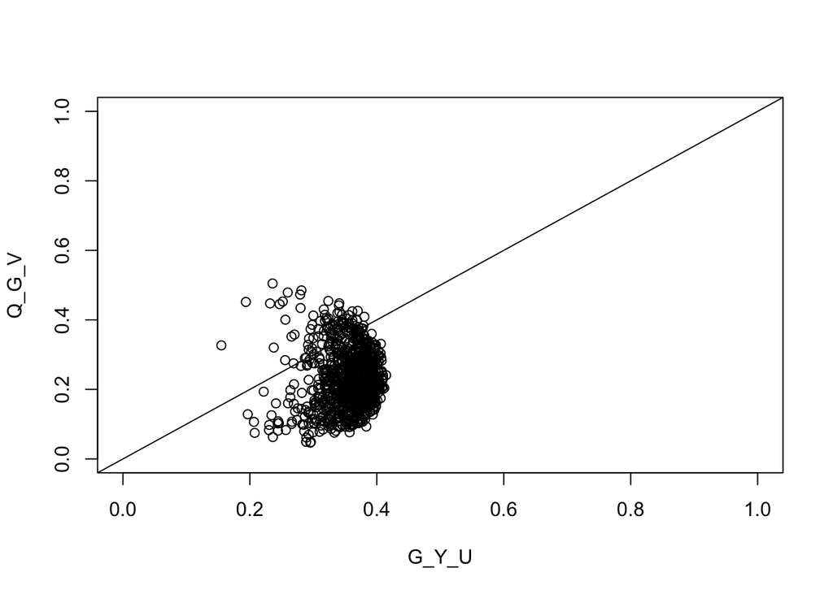

```r
#scatter plot of quantile against G(Y,U)
plot(Q_G_V ~ G_Y_U, xlim = c(0,1), ylim = c(0,1))
abline(0,1)
```

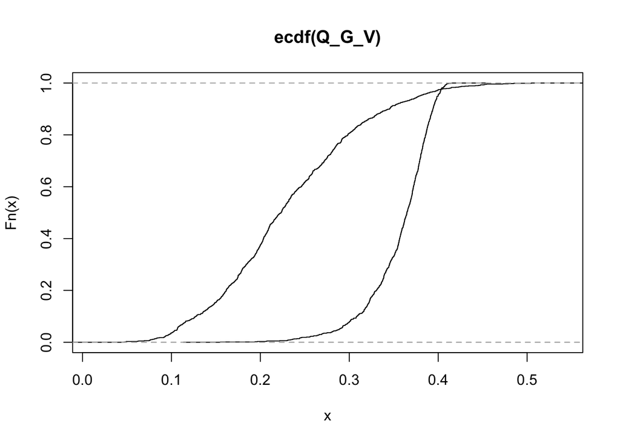

```r
#ECDFs
plot(ecdf(Q_G_V))
plot(ecdf(G_Y_U), add = T)
```

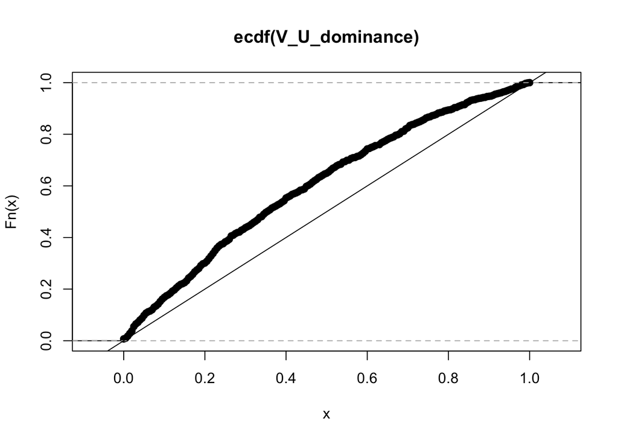

```r
#is G_Y_V below G_Y_U at a rate that looks like a valid p-value
V_U_dominance <- rowMeans(G_Y_V <= G_Y_U)
#doesn't seem to be...
plot(ecdf(V_U_dominance))
abline(0,1)
```

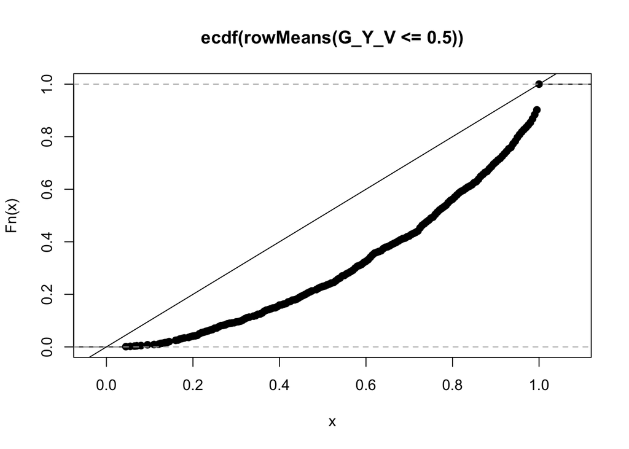

```r
#the p values (comparing to mu_0) are in fact dominated by a uniform
plot(ecdf(rowMeans(G_Y_V <= .5)))
abline(0,1)
```